# Assignment 3

## Number of after school locations in each neighborhood

How many after school locations are in each Denver neighborhood?

The northeasternmost neighborhood only contains Denver International Airport, so there’s no surprise that there are no after school locations there.

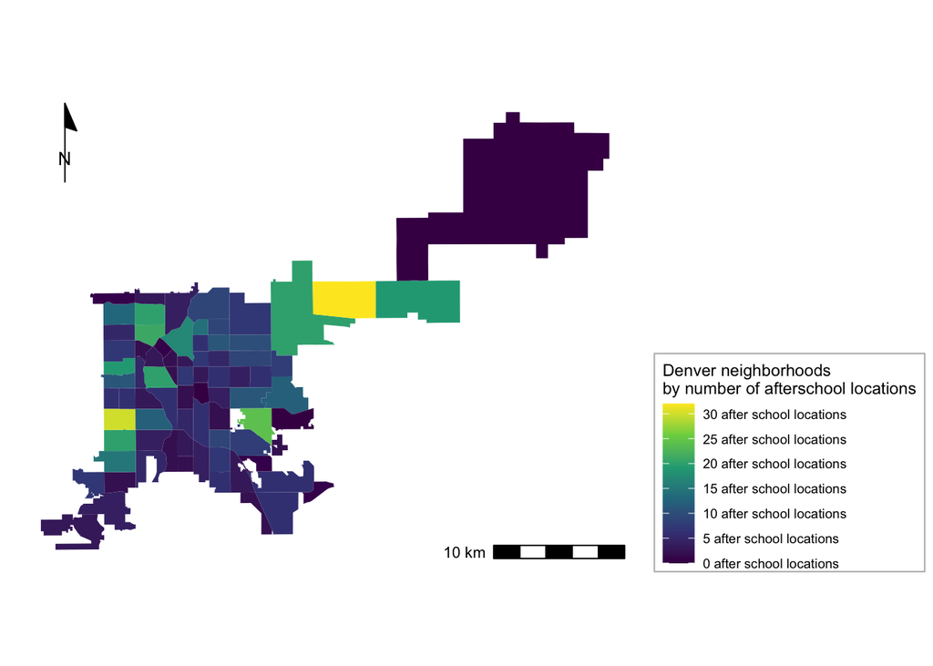

```r
nhoods <- nhoods %>%
  mutate(num_afterschool = lengths(st_covers(nhoods, afterschool)))

ggplot(nhoods) +
  geom_sf(color = NA,
          aes(fill = num_afterschool)) +
  scale_fill_viridis_c(name = "Denver neighborhoods\nby number of afterschool locations",
                       breaks = breaks <- seq(0, 40, by = 5),
                       labels = paste(prettyNum(breaks, big.mark = ","),
                                      "after school locations")) +
  annotation_scale(location = "br") +
  annotation_north_arrow(location = "tl",
                         style = north_arrow_minimal()) +

theme_map() +
  theme(legend.position = "right", legend.background = element_rect(fill = alpha("white", 0.5),
                                         color = "gray"))
```

## Number of liquor licenses in each neighborhood

How many liquor licenses are in each Denver neighborhood?

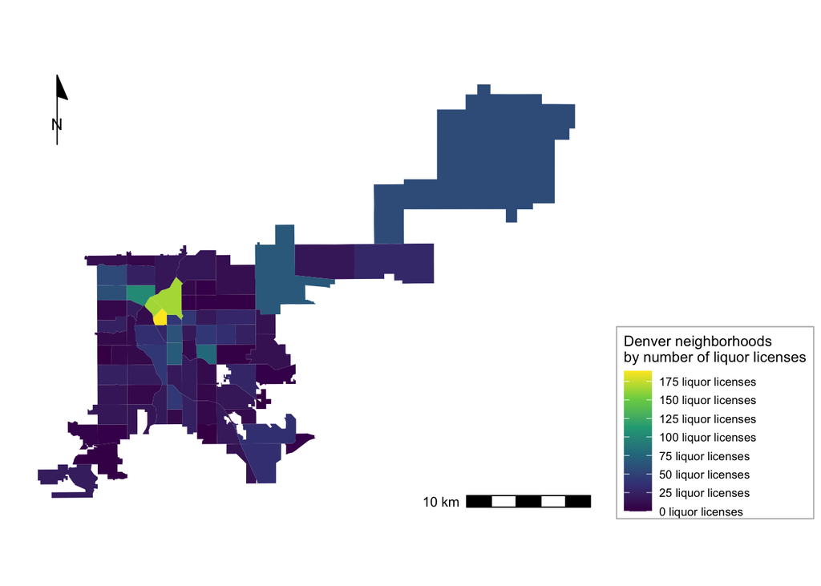

```r
nhoods <- nhoods %>%
  mutate(num_liquorlic = lengths(st_covers(nhoods, liquorlic)))

ggplot(nhoods) +
  geom_sf(color = NA,
          aes(fill = num_liquorlic)) +
  scale_fill_viridis_c(name = "Denver neighborhoods\nby number of liquor licenses",
                       breaks = breaks <- seq(0, 200, by = 25),
                       labels = paste(prettyNum(breaks, big.mark = ","),
                                      "liquor licenses")) +
  annotation_scale(location = "br") +
  annotation_north_arrow(location = "tl",
                         style = north_arrow_minimal()) +

theme_map() +
  theme(legend.position = "right", legend.background = element_rect(fill = alpha("white", 0.5),
                                         color = "gray"))
```

## The density of liquor license locations in farmers market districts

Admittedly, I wasn’t sure how to adjust the scale so that the maximum density was displayed with the yellow. You can see that the density is slightly greater in the downtown Denver area.

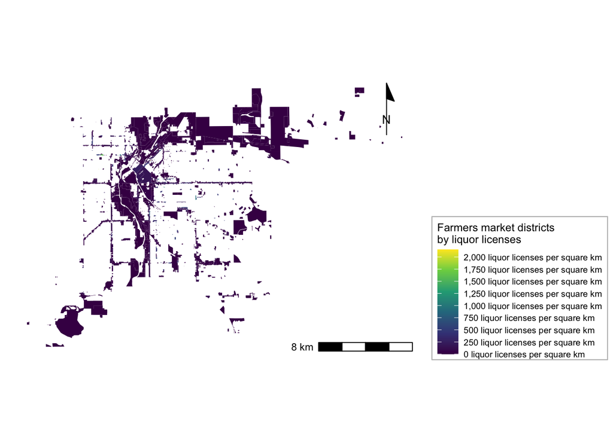

```r
farmersmarket <- farmersmarket %>%
  mutate(num_liquorlic = lengths(st_covers(farmersmarket, liquorlic)))

farmersmarket <- farmersmarket %>%
  mutate(area = set_units(st_area(farmersmarket), km^2)) %>%
  mutate(liquorlic_dens = as.numeric(num_liquorlic / area))

ggplot(farmersmarket) +
  geom_sf(color = NA,
          aes(fill = liquorlic_dens)) +
    scale_fill_viridis_c(name =
                           "Farmers market districts\nby liquor licenses",
                       breaks = breaks <- seq(0, 2000, by = 250),
                       labels = paste(prettyNum(breaks, big.mark = ","),
                                      "liquor licenses per square km")) +
  annotation_scale(location = "br") +
  annotation_north_arrow(location = "tr",
                         style = north_arrow_minimal()) +
theme_map() +
  theme(legend.position = "right",
    legend.background = element_rect(fill = alpha("white", 0.5),
                                         color = "gray"))
```

## The average distance between an after school location and a liquor license

To find the average distance from an after school program to a liquor license, first we find the distances of after school programs to their nearest liquor license.

```r
afterschool <- afterschool %>%
  mutate(liquorlic_dist = st_nn(afterschool, liquorlic,
                           returnDist = TRUE)$dist) %>%
  mutate(liquorlic_dist = as.numeric(liquorlic_dist))
```

Then I can calculate the average distance from an after school program to the nearest liquor license.

```r
avg_liquorlic_dist <- mean(afterschool$liquorlic_dist)

avg_liquorlic_dist
```

```
## [1] 418.0913
```

I can make a map that represents how far each after school program is to a liquor license.

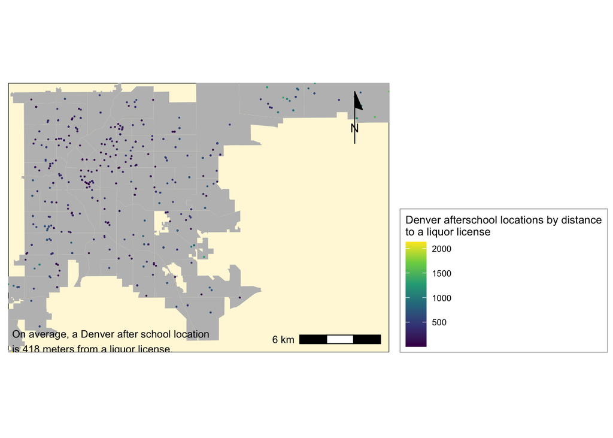

```r
right_side <- st_bbox(afterschool)$xmax
left_side  <- st_bbox(afterschool)$xmin
top_side <- st_bbox(afterschool)$ymax
bottom_side <- st_bbox(afterschool)$ymin


ggplot(nhoods) +
  geom_sf(fill = "gray", color = NA) +
  geom_sf(data = afterschool, size = 0.1,
          aes(color = liquorlic_dist)) +
  coord_sf(xlim = c(left_side, right_side),
           ylim = c(bottom_side, top_side), expand = FALSE) +
  scale_color_viridis_c(name =
                          "Denver afterschool locations by distance\nto a liquor license") +
  annotation_scale(location = "br") +
  annotation_north_arrow(location = "tr",
                         style = north_arrow_minimal()) +
  annotate(geom = "text", x = left_side + 300,
           y = bottom_side,
           label = paste("On average, a Denver after school location\nis ",
                         prettyNum(avg_liquorlic_dist, digits = 3),
                         " meters from a liquor license.",
                         sep = ""),
           hjust = 0, vjust = 0, size = 3) +
  theme_map() +
  theme(legend.position = "right", panel.background = element_rect(fill = "cornsilk1"),
        legend.background = element_rect(fill = alpha("white", 0.5),
                                         color = "gray"))
```

## Farmers Market districts that overlap with Denver neighborhoods

```r
nhoods <- nhoods %>%
  mutate(num_fmarket = lengths(st_overlaps(nhoods, farmersmarket))) %>%
  mutate(has_fmarket = num_fmarket > 0)
```

How many neighborhoods overlap with farmers market districts?

```r
n_fmarket_nhoods <- sum(nhoods$has_fmarket)

n_fmarket_nhoods
```

```
## [1] 77
```

Again, the northeasternmost neighborhood only contains Denver International Airport, so it’s not surprising that there is no zoned district allowing farmers markets within that neighborhood.

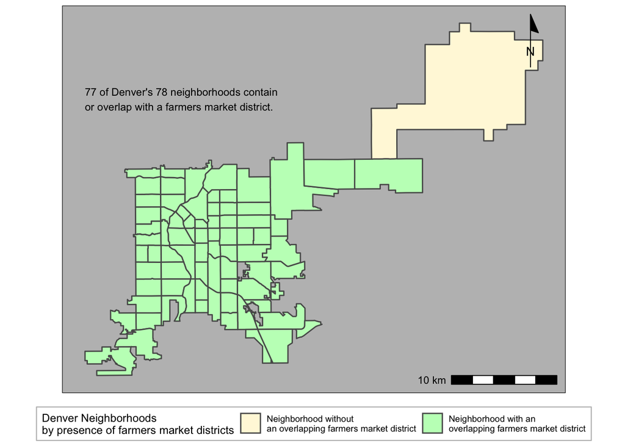

```r
left_side  <- st_bbox(farmersmarket)$xmin
top_side <- st_bbox(farmersmarket)$ymax

ggplot(nhoods) +
  geom_sf(fill = "lightblue", color = NA) +
  geom_sf(data = nhoods,
          aes(fill = has_fmarket)) +
  scale_fill_manual(values = c("cornsilk1", "darkseagreen1"),
          name = "Denver Neighborhoods\nby presence of farmers market districts",
          labels = c("Neighborhood without\nan overlapping farmers market district",
                     "Neighborhood with an\noverlapping farmers market district")) +
  annotation_scale(location = "br") +
  annotation_north_arrow(location = "tr",
                         style = north_arrow_minimal()) +
  annotate(geom = "text", x = left_side,
           y = top_side+3000,
           label = paste(n_fmarket_nhoods ,
                         "of Denver's",
                         length(nhoods$Name),
                         "neighborhoods contain\nor overlap with",
                         "a farmers market district."),
           hjust = 0, vjust = 0, size = 3) +
  theme_map() +
  theme(legend.position = "bottom",
        panel.background = element_rect(fill = "gray"),
        legend.background = element_rect(fill = alpha("white", 0.5),
                                         color = "gray"))
```

## After school locations in Farmers Market Districts

It’s interesting to note the connections between after school locations and farmers market districts. Typically, farmers markets tend to pop up in areas with middle class or higher SES residents. After school programs can vary, typically appearing mostly in more affluent areas although also often in low-SES areas where programs like the YMCA or Boys and Girls Clubs are found. In any case, this analysis shows the farmers market districts in the downtown area containing higher number of afterschool locations (which might be explained simply by the area’s density). The few bright spots in the northeast could reflect the growing wealth towards the northeast.

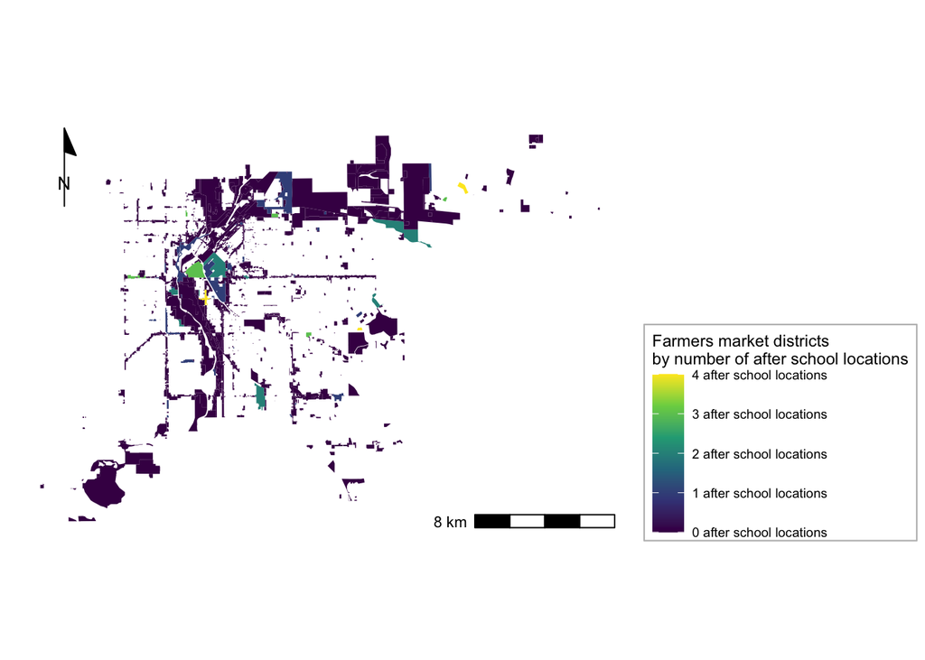

```r
farmersmarket <- farmersmarket %>%
  mutate(num_afterschool = lengths(st_covers(farmersmarket, afterschool)))

ggplot(farmersmarket) +
  geom_sf(color = NA,
          aes(fill = num_afterschool)) +
  scale_fill_viridis_c(name = "Farmers market districts\nby number of after school locations",
                       breaks = breaks <- seq(0, 8, by = 1),
                       labels = paste(prettyNum(breaks, big.mark = ","),
                                      "after school locations")) +
  annotation_scale(location = "br") +
  annotation_north_arrow(location = "tl",
                         style = north_arrow_minimal()) +

theme_map() +
  theme(legend.position = "right", legend.background = element_rect(fill = alpha("white", 0.5),
                                         color = "gray"))
```

## Liquor license locations in Farmers Market Districts

I’m not sure that this map offers anything compelling, but it further highlights that Downtown Denver contains a high concentration of liquor licenses.

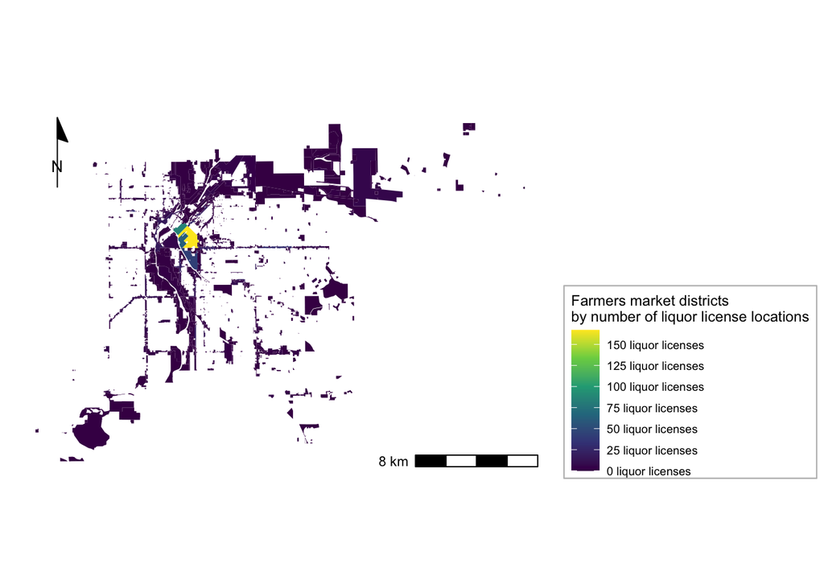

```r
farmersmarket <- farmersmarket %>%
  mutate(num_liquorlic = lengths(st_covers(farmersmarket, liquorlic)))

ggplot(farmersmarket) +
  geom_sf(color = NA,
          aes(fill = num_liquorlic)) +
  scale_fill_viridis_c(name = "Farmers market districts\nby number of liquor license locations",
                       breaks = breaks <- seq(0, 150, by = 25),
                       labels = paste(prettyNum(breaks, big.mark = ","),
                                      "liquor licenses")) +
  annotation_scale(location = "br") +
  annotation_north_arrow(location = "tl",
                         style = north_arrow_minimal()) +

theme_map() +
  theme(legend.position = "right", legend.background = element_rect(fill = alpha("white", 0.5),
                                         color = "gray"))
```